# NBA 2020 Season Statistics Analysis

# Turnovers

Although it's good to analyze the good statistics such as three point attempts and field goals made. We also must turn to the negative statistics as well. One example is turnovers. If you're not familiar with turnovers, it's when a player looses posession. Also another impacting statistic is the Personal Foul count. Now we can try to see if there's a correlation between the two. For example, in a game if a player is consistently turning the ball over. Is that player going to be more aggresive and become more succeptible to a personal foul than a player with less turnovers? Our graph provides us with an answer to that. With the usage of linear regression we can see that the higher the amount of turnovers a player has, the higher amount of personal fouls that player will commit in that game. This is not concrete evidence, as time played could also play a big role in the amount of personal fouls. But we have a good amount of evidence to claim that turnovers may be influential in players getting more personal fouls based on a higher count of turnovers.

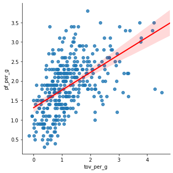

```python
sns.lmplot("tov_per_g", "pf_per_g", df2, x_jitter=.40,line_kws={'color': 'red'})
```

# Does Salary Make a Difference?

The following section will contain multiple graphs with the intention of providing information to see the cost effectiveness of players in the NBA. Whether or not the salary makes as big of an impact for each player as we may think it does.

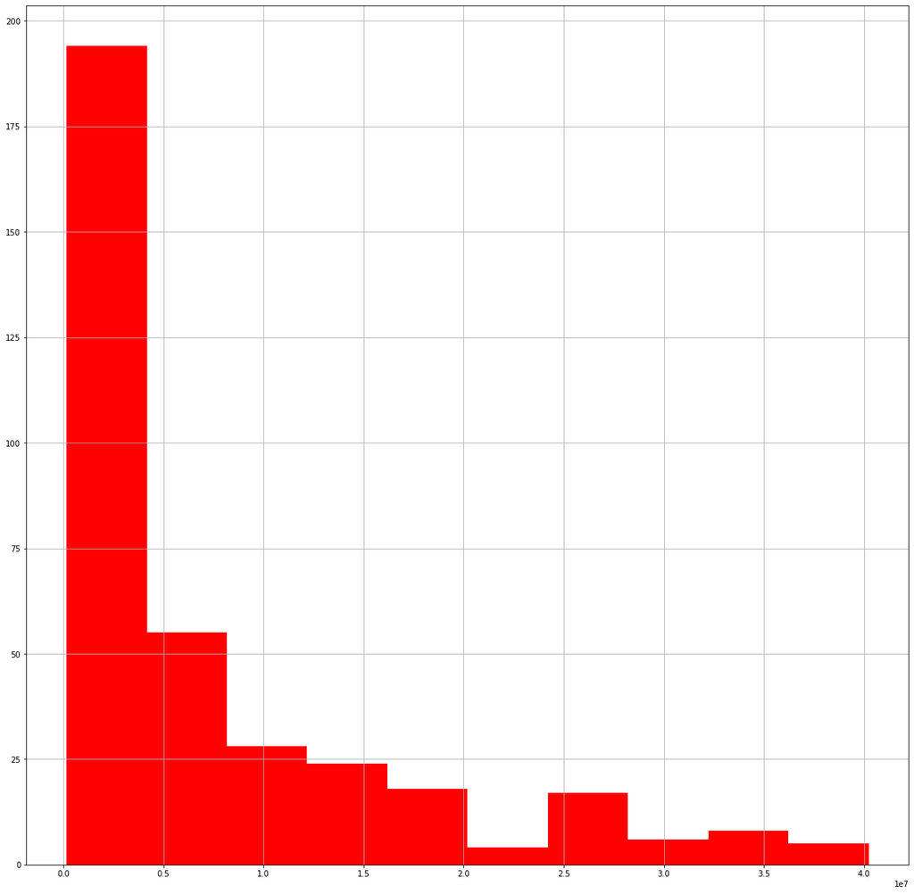

```python
df2['p_salary'].hist(figsize=(20,20),color='red')
```

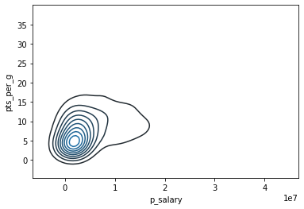

```python
sns.kdeplot(df2['p_salary'], df2['pts_per_g'])
```

The graph shows that the higher performing players **do on average get more salary than others**. This is more notible by the growth on the right hand side of the cluster.

# Creating our Model

We will be making our model soon, but first we must select what variables may have close relations with one another. We are able to better view our cinformation via a heatmap which allows us to see where variables are having higher impact on one another. This allows us to better pick what variables we'd like to test in our model as being influencial to one another.

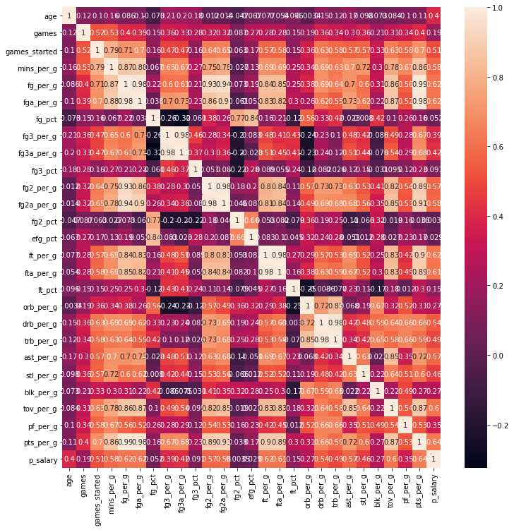

```python
plt.figure(figsize=(12,12))
sns.heatmap(df2.corr(), annot=True)
```

# Cleaning

Although it seems as though we've done this multiple times. It's important we clean our data again just in case. Prior to fitting our model we want to be sure that the data is prestine. To triple check we use autoclean which is a public library source which will clean our data for us.

```python
my_clean_data = autoclean(df2)
my_clean_data
```

|  | player | position | age | team | games | games_started | mins_per_g | fg_per_g | fga_per_g | fg_pct | ... | orb_per_g | drb_per_g | trb_per_g | ast_per_g | stl_per_g | blk_per_g | tov_per_g | pf_per_g | pts_per_g | p_salary |
| --- | --- | --- | --- | --- | --- | --- | --- | --- | --- | --- | --- | --- | --- | --- | --- | --- | --- | --- | --- | --- | --- |
| 0 | 313 | 0 | 26 | 20 | 63 | 63 | 26.7 | 4.5 | 7.6 | 0.592 | ... | 3.3 | 6.0 | 9.3 | 2.3 | 0.8 | 1.1 | 1.5 | 1.9 | 10.9 | 25842697.0 |
| 1 | 22 | 1 | 22 | 15 | 72 | 72 | 33.6 | 6.1 | 11.0 | 0.557 | ... | 2.4 | 7.8 | 10.2 | 5.1 | 1.1 | 1.3 | 2.8 | 2.5 | 15.9 | 3454080.0 |
| 2 | 215 | 0 | 34 | 26 | 53 | 53 | 33.1 | 7.4 | 15.0 | 0.493 | ... | 1.9 | 5.5 | 7.4 | 2.4 | 0.7 | 1.6 | 1.4 | 2.4 | 18.9 | 26000000.0 |
| 3 | 126 | 10 | 24 | 14 | 38 | 0 | 18.9 | 3.1 | 6.6 | 0.466 | ... | 0.2 | 2.0 | 2.2 | 1.4 | 0.3 | 0.1 | 0.9 | 1.4 | 8.7 | 2429400.0 |
| 4 | 157 | 0 | 21 | 2 | 70 | 64 | 26.5 | 4.3 | 6.6 | 0.649 | ... | 3.1 | 6.5 | 9.6 | 1.6 | 0.6 | 1.3 | 1.1 | 2.3 | 11.1 | 2376840.0 |
| ... | ... | ... | ... | ... | ... | ... | ... | ... | ... | ... | ... | ... | ... | ... | ... | ... | ... | ... | ... | ... | ... |
| 354 | 79 | 4 | 27 | 6 | 73 | 5 | 21.5 | 2.6 | 5.6 | 0.462 | ... | 1.0 | 2.9 | 3.8 | 3.3 | 1.2 | 0.3 | 1.0 | 1.3 | 6.9 | 9473684.0 |
| 355 | 323 | 1 | 31 | 3 | 64 | 16 | 24.9 | 4.2 | 9.4 | 0.448 | ... | 1.5 | 3.5 | 4.9 | 1.8 | 1.4 | 0.4 | 1.6 | 2.1 | 10.3 | 12900000.0 |
| 356 | 333 | 4 | 21 | 0 | 60 | 60 | 35.3 | 9.1 | 20.8 | 0.437 | ... | 0.5 | 3.7 | 4.3 | 9.3 | 1.1 | 0.1 | 4.8 | 1.7 | 29.6 | 6273000.0 |
| 357 | 59 | 0 | 27 | 4 | 58 | 39 | 23.1 | 4.3 | 8.3 | 0.524 | ... | 2.8 | 4.3 | 7.1 | 1.5 | 0.7 | 0.4 | 1.3 | 2.4 | 11.1 | 14471910.0 |
| 358 | 138 | 0 | 22 | 12 | 72 | 70 | 18.4 | 3.3 | 5.3 | 0.613 | ... | 2.7 | 4.8 | 7.5 | 1.1 | 0.2 | 0.9 | 0.8 | 2.3 | 8.3 | 6481482.0 |

359 rows × 30 columns

# Creating a Model with Salary

```python
y = df2['p_salary']
X = df2.drop(['p_salary'], axis =1)
reg = linear_model.Ridge (alpha = .1)
reg.fit(X,y)
reg_y = reg.predict(X)
Ridge(alpha=0.5, copy_X=True, fit_intercept=True, max_iter=None,
      normalize=False, random_state=None, solver='auto', tol=0.005)
print (reg.coef_)

print(reg.intercept_)

print ("The mean square error: ", mean_squared_error(y, reg_y))

print ("Variance ", explained_variance_score(y, reg_y))
```

```
[ 2.88160785e+03  1.68906905e+04  6.55571660e+05  3.73602218e+04
 -7.17237515e+04  5.19533010e+04 -7.46422967e+04 -2.74504086e+06
  1.00638272e+07  4.32230022e+06 -9.21828971e+06 -8.28132503e+06
 -1.05174762e+06 -2.66128002e+06 -1.01412904e+07 -1.89112773e+06
 -5.25545266e+06  1.51015569e+06 -2.48316152e+06 -2.91456549e+06
  6.35380613e+06  6.03307090e+06 -5.03135058e+06  1.22936942e+06
  1.76270759e+06  1.48135653e+06 -1.88941009e+06 -1.51438587e+06
  3.06615145e+06]
-11544652.689129412
The mean square error:  32451725156977.203
Variance  0.6156194430572148
```

# Creating another model, but with Lasso

We then try again, with a different model but the same variable. Using salary as our main variable again, we get a similar value of 61% variance. This provides us with a good response to our theory that salary was incredibly impactful to other statistics. After the creation of the models. We see that the salaries are not as significantly impactful to statistics as we may have though it was.

```python
y = df2['p_salary']
X = df2.drop(['p_salary'], axis =1)
reg = linear_model.Lasso(alpha = 0.1)
reg.fit(X, y)
reg_y = reg.predict(X)

print ("Mean Square error: ", mean_squared_error(y, reg_y))
print ("variance: ", explained_variance_score(y, reg_y))
print ('Coefficients: ', reg.coef_)
print ("y-intercept ", reg.intercept_)
```

```
Mean Square error:  32851859036008.527
variance:  0.6108799821339588
Coefficients:  [ 2.25620155e+03  1.66170614e+04  6.62583894e+05  4.19943324e+04
 -7.10917270e+04  5.19047628e+04 -7.18115259e+04  1.19065435e+06
  6.15519020e+05  1.11572152e+07 -6.06026324e+06  1.28799502e+06
 -4.54954085e+05 -1.76484753e+06 -7.43403915e+05 -2.96578602e+06
 -1.18089129e+07  3.60585290e+06 -2.31880716e+06 -3.09782123e+06
  3.87624018e+06  3.55324729e+06 -2.54025141e+06  1.21543047e+06
  1.72379972e+06  1.44417809e+06 -1.85003199e+06 -1.57373228e+06
  6.85004755e+05]
y-intercept  -11038251.663415447
```

# Sorting Our Models Estimated Significant Variables

The following printed variables are the variables which our model believed to have had the largest significance to our player salary. First, 3 point attempts and field goal attempts have the highest significance to our player salary as shown by our model. This is quite difficult to understand from a practical standpoint where the attempts don't directly contribute to victory rather the amount converged does.

```python
y = df2['p_salary']
X = df2.drop(['p_salary'], axis =1)
lr = lm.LinearRegression()
rfe = RFE(lr, n_features_to_select=2)
rfe_y = rfe.fit(X,y)

print("Features")
print (sorted(zip(map(lambda x: x, rfe.ranking_), X.columns)))
```

[output not shown]

# Attempting Different Variables

In the following cell we attempted to test other variables that we though would have the highest amount of impact to player salary, such as field goal percentage, points per game and many other columns of information we believed would have the highest impact in player salary. Once the model ran, we received a variance of 57%, which is lower than the original model. This means that although we may think directly that more points made would mean a higher salary it's not necessarily true.

```python
x = df2[['fg_pct','pts_per_g','trb_per_g', 'ast_per_g','tov_per_g','age','games']]
Y = df2['p_salary']
model1 = lm.LinearRegression()
model1.fit(x, Y)
model1_y = model1.predict(x)
coef = ["%.3f" % i for i in model1.coef_]
xcolumns = [ i for i in x.columns ]
zip(xcolumns, coef)
print("mean square error", mean_squared_error(y, model1_y))


print ("y-intercept ", model1.intercept_)

print ("variance ", explained_variance_score(y, model1_y))

print ('Coefficients: ', model1.coef_)
```

```
mean square error 36162691769392.28
y-intercept  -13433098.938114982
variance  0.5716642016524446
Coefficients:  [-7460982.67325323   629802.7131737   1032100.82138702  1448678.93882853
 -1569774.14699546   656322.03454308   -73935.7666264 ]
```

# Mean Squared Error

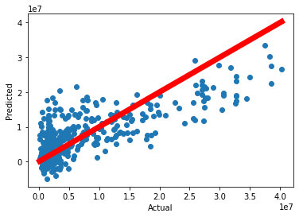

```python
plt.subplots()
plt.scatter(y, model1_y)
plt.plot([y.min(), y.max()], [y.min(), y.max()], lw=7,color='red')
plt.xlabel('Actual')
plt.ylabel('Predicted')
plt.show()
```